# Hypothesis Testing-Stroop Effect

### 1.What is our independent variable? What is our dependent variable?

The independent variable in this case is test conditions whether the task has Congruent and Incongruent conditions .The Dependent variable here in the experiment is the Time that has been taken to identify the colour.In this case it is dependent because this variable changes when the test conditions are changed.

### 2. What is an appropriate set of hypotheses for this task? What kind of statistical test do you expect to perform? Justify your choices.

H_0-Null Hypothesis-The null hypothesis states that the population mean of congruent task(μ_c) is equal to population mean of Incongruent tasks(μ_i).

H_a-Alternative hypothesis-In alternative Hypothesis the population mean of congruent tasks(μ_c) is less than the population mean of Incongruent tests(μ_i).

H_0: μ_c=μ_i

H_a: μ_c<μ_i which means μ_i-μ_c>0

In order to test which hypothesis is true we need to do a one tailed t-test because here we are trying to compare whether Incongruent or Congruent conditions will effect in recognizing the color of the word.We are trying to see whether the interference(Incongruent condition) trying to slow down in recognizing the color of the word and hence I would use a one tailed t-test in this experiment.

### 3. Report some descriptive statistics regarding this dataset. Include at least one measure of central tendency and at least one measure of variability.

```python
import numpy as np
import pandas as pd

Stroopdata = pd.read_csv('C:/Users/srava/Desktop/Udacity_ProjectFiles/stroopdata.csv')

Stroopdata['Difference']=Stroopdata.Incongruent-Stroopdata.Congruent

Stroopdata
```

|  | Congruent | Incongruent | Difference |
| --- | --- | --- | --- |
| 0 | 12.079 | 19.278 | 7.199 |
| 1 | 16.791 | 18.741 | 1.950 |
| 2 | 9.564 | 21.214 | 11.650 |
| 3 | 8.630 | 15.687 | 7.057 |
| 4 | 14.669 | 22.803 | 8.134 |
| 5 | 12.238 | 20.878 | 8.640 |
| 6 | 14.692 | 24.572 | 9.880 |
| 7 | 8.987 | 17.394 | 8.407 |
| 8 | 9.401 | 20.762 | 11.361 |
| 9 | 14.480 | 26.282 | 11.802 |
| 10 | 22.328 | 24.524 | 2.196 |
| 11 | 15.298 | 18.644 | 3.346 |
| 12 | 15.073 | 17.510 | 2.437 |
| 13 | 16.929 | 20.330 | 3.401 |
| 14 | 18.200 | 35.255 | 17.055 |
| 15 | 12.130 | 22.158 | 10.028 |
| 16 | 18.495 | 25.139 | 6.644 |
| 17 | 10.639 | 20.429 | 9.790 |
| 18 | 11.344 | 17.425 | 6.081 |
| 19 | 12.369 | 34.288 | 21.919 |
| 20 | 12.944 | 23.894 | 10.950 |
| 21 | 14.233 | 17.960 | 3.727 |
| 22 | 19.710 | 22.058 | 2.348 |
| 23 | 16.004 | 21.157 | 5.153 |

```python
Stroopdata.describe()
```

|  | Congruent | Incongruent | Difference |
| --- | --- | --- | --- |
| count | 24.000000 | 24.000000 | 24.000000 |
| mean | 14.051125 | 22.015917 | 7.964792 |
| std | 3.559358 | 4.797057 | 4.864827 |
| min | 8.630000 | 15.687000 | 1.950000 |
| 25% | 11.895250 | 18.716750 | 3.645500 |
| 50% | 14.356500 | 21.017500 | 7.666500 |
| 75% | 16.200750 | 24.051500 | 10.258500 |
| max | 22.328000 | 35.255000 | 21.919000 |

### 4.Provide one or two visualizations that show the distribution of the sample data. Write one or two sentences noting what you observe about the plot or plots.

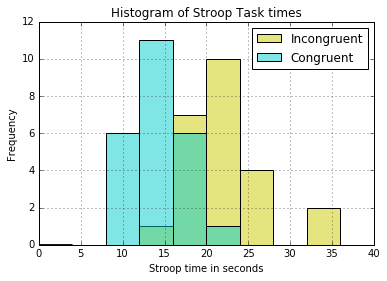

```
The Above figure shows the frequency distribution of the Congruent and Incongruent Stroop Task time taken by the samples
```

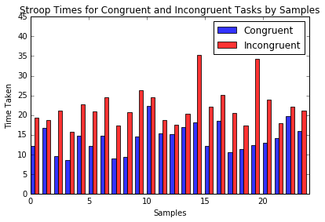

```
The above graphs tells us that the Samples have taken much longer time for Incongruent task than Congruent Tasks
```

```python
%matplotlib inline
import numpy as np
import pandas as pd
import matplotlib.pyplot as plt


Stroopdata = pd.read_csv('C:/Users/srava/Desktop/Udacity_ProjectFiles/stroopdata.csv')

Congruent=Stroopdata.Congruent
Incongruent=Stroopdata.Incongruent
plt.figure()
Incongruent.hist(color=(0.8, 0.8, 0, 0.5), bins=10, range=(0,40), label='Incongruent', stacked=False)
Congruent.hist(color=(0, 0.8, 0.8, 0.5), bins=10, range=(0,40), label='Congruent', stacked=False)

plt.ylim((0,12))
plt.legend(prop={'size': 12})
plt.xlabel('Stroop time in seconds')
plt.ylabel('Frequency')
plt.title('Histogram of Stroop Task times')
plt.show()

print("The Above figure shows the frequency distribution of the Congruent and Incongruent Stroop Task time taken by the samples")


fig, ax = plt.subplots()

n=24
index=np.arange(n)
bar_width = 0.35

opacity = 0.8
error_config = {'ecolor': '0.3'}


rects1 = plt.bar(index, Congruent, bar_width,
                 alpha=opacity,
                 color='b',
                 error_kw=error_config,
                 label='Congruent')
rects2 = plt.bar(index + bar_width, Incongruent, bar_width,
                 alpha=opacity,
                 color='r',
                 error_kw=error_config,
                 label='Incongruent')
plt.xlabel('Samples')
plt.ylabel('Time Taken')
plt.xlim((0,24))
plt.ylim((0,45))
plt.title('Stroop Times for Congruent and Incongruent Tasks by Samples')
plt.legend()

plt.tight_layout()
plt.show()

print("The above graphs tells us that the Samples have taken much longer time for Incongruent task than Congruent Tasks")
```

### 5.Now, perform the statistical test and report your results. What is your confidence level and your critical statistic value? Do you reject the null hypothesis or fail to reject it? Come to a conclusion in terms of the experiment task. Did the results match up with your expectations?

```python
import numpy as np
import pandas as pd

from scipy.stats import stats
Stroopdata = pd.read_csv('C:/Users/srava/Desktop/Udacity_ProjectFiles/stroopdata.csv')

Stroopdata['Difference']=Stroopdata.Incongruent-Stroopdata.Congruent
t,p=ttest_1samp(Stroopdata.Difference,popmean=0)
print ("ttest t=" + str(t))
print("p=" + str(p))
```

```
ttest t=8.02070694411
p=4.10300058571e-08
```

### References:

http://www.ats.ucla.edu/stat/mult_pkg/faq/general/tail_tests.htm https://people.richland.edu/james/lecture/m170/tbl-t.html http://matplotlib.org/examples/api/barchart_demo.html https://en.wikipedia.org/wiki/Student%27s_t-test#Paired_samples http://docs.scipy.org/doc/scipy/reference/generated/scipy.stats.ttest_1samp.html http://matatat.org/p-values-statistical-testing.html https://people.richland.edu/james/lecture/m170/tbl-t.html